# TF Library Screen Repeat Analysis

pdevant

2026-04-01

## Overview

This notebook documents the plotting workflow while staying close to the original analysis script. Only the two final figures are retained:

- the donor 1 versus donor 2 z-score correlation plot colored by paired FDR
- the four-donor volcano plot from the 100k permutation analysis using z-score bins of 1 to 3 and above 3

```r
knitr::opts_chunk$set(
  echo = TRUE,
  fig.width = 7,
  fig.height = 6,
  fig.align = "center"
)

library(ggplot2)
library(ggrepel)
library(dplyr)
library(grid)
```

## Read and Merge Gene Summary Files

This section follows the same structure as the original script and keeps the donor-level MAGeCK gene summary files separate before merging them by `id`.

```r
df_D1 <- read.csv("/Users/pdevant/results/D1_hi_vs_low_2025-05-08.gene_summary.csv", header = TRUE)

df_D2 <- read.csv("/Users/pdevant/results/D2_hi_vs_low_2025-05-08.gene_summary.csv", header = TRUE)

df_D3 <- read.csv("/Users/pdevant/results_CD80-REP/CD80_D3_hi_vs_low2026-01-30.gene_summary.csv", header = TRUE)

df_D4 <- read.csv("/Users/pdevant/results_CD80-REP/CD80_D4_hi_vs_low2026-01-30.gene_summary.csv", header = TRUE)

add_suffix <- function(df, suffix, idcol = "id") {
  names(df) <- ifelse(names(df) == idcol, idcol, paste0(names(df), suffix))
  df
}

df_D1 <- add_suffix(df_D1, "_D1")
df_D2 <- add_suffix(df_D2, "_D2")
df_D3 <- add_suffix(df_D3, "_D3")
df_D4 <- add_suffix(df_D4, "_D4")

merged_df <- Reduce(function(x, y) merge(x, y, by = "id", all = TRUE),
                    list(df_D1, df_D2, df_D3, df_D4))
```

## Read Combined 100k Permutation Analysis

This section also follows the original script and uses the combined four-donor 100k permutation result as the source of paired FDR values and the volcano plot.

```r
df_D1234_CD80_Perm100k <- read.csv("/Users/pdevant/results_CD80_All-donors_perm100k/CD80_D1234_hi_vs_low2026-02-18.gene_summary.csv", header = TRUE)

df_D1234_CD80_Perm100k <- subset(df_D1234_CD80_Perm100k, id != "Non-Targeting")

df_D1234_CD80_Perm100k$z_score <- as.numeric(scale(df_D1234_CD80_Perm100k$`neg.lfc`))

df_D1234_CD80_Perm100k$FDR <- ifelse(
  df_D1234_CD80_Perm100k$pos.lfc > 0,
  df_D1234_CD80_Perm100k$pos.fdr,
  df_D1234_CD80_Perm100k$neg.fdr
)

df_D1234_CD80_Perm100k$neglog10_FDR <- -log10(df_D1234_CD80_Perm100k$FDR)
```

## Volcano Plot for Combined 100k Permutation Analysis

This block keeps the original logic of:

- using the 100k permutation combined dataset
- z-scoring `neg.lfc`
- defining bins with `z = 1` and `z = 3`
- coloring only when the FDR threshold is passed

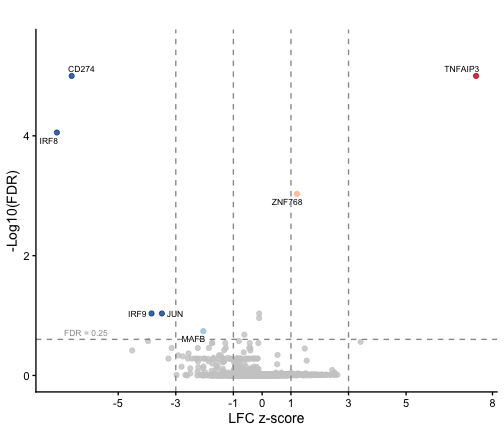

```r
FDR_threshold <- 0.25
z_lo <- 1
z_hi <- 3

df_D1234_CD80_Perm100k$ColorGroup <- with(df_D1234_CD80_Perm100k, ifelse(
  FDR < FDR_threshold & z_score >= z_hi, "Up_hi",
  ifelse(FDR < FDR_threshold & z_score >= z_lo & z_score < z_hi, "Up_lo",
         ifelse(FDR < FDR_threshold & z_score <= -z_hi, "Down_hi",
                ifelse(FDR < FDR_threshold & z_score <= -z_lo & z_score > -z_hi,
                       "Down_lo",
                       "Neutral")
         )
  )
))

label_df <- subset(df_D1234_CD80_Perm100k, FDR < FDR_threshold & abs(z_score) >= z_lo)

y_fdr <- -log10(FDR_threshold)
x_fdr_label <- min(df_D1234_CD80_Perm100k$z_score, na.rm = TRUE) + 0.25
x_main <- df_D1234_CD80_Perm100k$z_score
main_breaks <- sort(unique(c(pretty(x_main), -8, 8, -z_hi, -z_lo, 0, z_lo, z_hi)))

zVolcanoCD80 <- ggplot(df_D1234_CD80_Perm100k, aes(x = z_score, y = neglog10_FDR)) +
  geom_point(aes(color = ColorGroup), alpha = 0.8, size = 2) +
  scale_color_manual(values = c(
    "Down_hi" = "#08519C",
    "Down_lo" = "#9ECAE1",
    "Neutral" = "gray80",
    "Up_lo"   = "#FCBBA1",
    "Up_hi"   = "#CB181D"
  )) +
  geom_text_repel(
    data = label_df,
    aes(label = id),
    size = 3,
    max.overlaps = Inf
  ) +
  geom_vline(
    xintercept = c(-z_lo, z_lo, -z_hi, z_hi),
    linetype = "dashed",
    color = "grey60"
  ) +
  geom_hline(yintercept = y_fdr, linetype = "dashed", color = "grey60") +
  annotate(
    "text",
    x = x_fdr_label,
    y = y_fdr,
    label = paste0("FDR = ", FDR_threshold),
    hjust = 0,
    vjust = -0.6,
    size = 3,
    color = "grey60"
  ) +
  scale_y_continuous(
    limits = c(0, max(df_D1234_CD80_Perm100k$neglog10_FDR) + 0.5)
  ) +
  coord_cartesian(clip = "off") +
  theme(
    legend.position = "none",
    plot.margin = margin(40, 30, 30, 30)
  ) +
  theme_classic(base_size = 14) +
  labs(
    title = "",
    x = "LFC z-score",
    y = "-Log10(FDR)"
  ) +
  scale_x_continuous(breaks = main_breaks) +
  theme(legend.position = "none")

print(zVolcanoCD80)
```

```r
ggsave(
  "/Users/pdevant/plots/tf_library_repeat_report/combined_perm100k_zscore_volcano_fdr_025.pdf",
  plot = zVolcanoCD80,
  width = 7,
  height = 6
)
```

## Donor 1 Versus Donor 2 Z-Score Correlation Colored by Paired FDR

This chunk preserves the original analysis logic:

- z-score donor 1 and donor 2 independently using `pos.lfc`
- merge the paired FDR from the combined 100k permutation analysis
- define the extreme concordant hit groups at `z > 3` and `z < -3`
- plot donor 1 versus donor 2 z-scores with points colored by paired FDR

```r
merged_df$z_score_D1 <- as.numeric(scale(merged_df$pos.lfc_D1))
merged_df$z_score_D2 <- as.numeric(scale(merged_df$pos.lfc_D2))

merged_df <- merged_df %>%
  left_join(
    df_D1234_CD80_Perm100k %>% select(id, FDR),
    by = "id"
  ) %>%
  rename(FDR_paired = FDR)

merged_df$group <- with(merged_df, ifelse(
  z_score_D1 > 3 & z_score_D2 > 3, "GroupA",
  ifelse(z_score_D1 < -3 & z_score_D2 < -3, "GroupB", "Other")
))

label_df <- subset(merged_df, group %in% c("GroupA", "GroupB"))
```

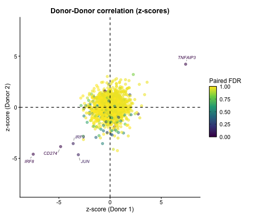

```r
set.seed(1)

p3_z_fig <- ggplot(merged_df,
                   aes(x = z_score_D1,
                       y = z_score_D2,
                       color = FDR_paired)) +
  geom_point(size = 2, alpha = 0.55) +
  scale_color_viridis_c(
    option = "D",
    direction = 1,
    name = "Paired FDR",
    limits = c(0, 1),
    oob = scales::squish,
    guide = guide_colorbar(
      barheight = unit(35, "mm"),
      barwidth  = unit(5, "mm"),
      ticks.colour = "black",
      frame.colour = "black"
    )
  ) +
  scale_x_continuous(limits = c(-8, 8)) +
  scale_y_continuous(limits = c(-8, 8)) +
  geom_vline(xintercept = 0, linetype = "dashed", color = "black", linewidth = 0.6) +
  geom_hline(yintercept = 0, linetype = "dashed", color = "black", linewidth = 0.6) +
  geom_text_repel(
    data = label_df,
    aes(label = id),
    seed = 1,
    size = 3,
    fontface = "italic",
    box.padding   = 0.6,
    point.padding = 0.7,
    force         = 10,
    force_pull    = 2,
    max.overlaps  = Inf,
    max.iter      = 50000,
    max.time      = 5,
    min.segment.length = 0,
    segment.color = "gray35",
    segment.size  = 0.35,
    segment.alpha = 0.9
  ) +
  coord_fixed(ratio = 1, clip = "off") +
  labs(
    title = "Donor-Donor correlation (z-scores)",
    x = "z-score (Donor 1)",
    y = "z-score (Donor 2)"
  ) +
  theme_classic(base_size = 12) +
  theme(
    plot.title = element_text(hjust = 0.5, face = "bold", size = 14),
    axis.title = element_text(size = 12),
    axis.text  = element_text(size = 11, color = "black"),
    legend.title = element_text(size = 12),
    legend.text  = element_text(size = 11),
    legend.position = "right",
    plot.margin = margin(10, 25, 10, 10)
  )

print(p3_z_fig)
```

```r
ggsave(
  "/Users/pdevant/plots/tf_library_repeat_report/donor_correlation_zscore_paired_fdr.pdf",
  plot = p3_z_fig,
  width = 7,
  height = 6
)
```